# Lesson 23: Inference for Bivariate Data

Homework

- Word Document
- PDF Document

## Solutions

**Please note that the steps show rounded numbers, but that the final answers to the problems are calculated without rounding.**

Problem

Part

Solution

1

-

Estimated linear regression equation:
$$\hat{Y} = b_0 + b_1X$$
True linear regression equation:
$$Y = \beta_0 + \beta_1X + \epsilon$$

2

-

See the [wiki](http://statistics.byuimath.com/index.php?title=Lesson_23:_Inference_for_Bivariate_Data#Checking_Requirements_of_Simple_Linear_Regression) for a review of this important concept.

3

A

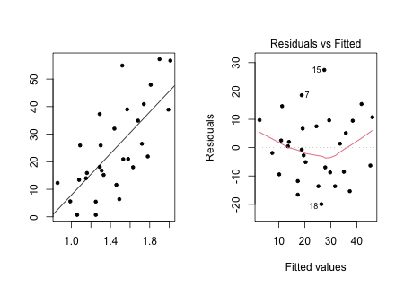

The appropriate graphs to check for a linear relationship are a scatterplot and a residual plot. The scatterplot seems to show a linear relationship and there is no pattern in the residual plot, so we can conclude that there is a linear relationship in the data.

3

B

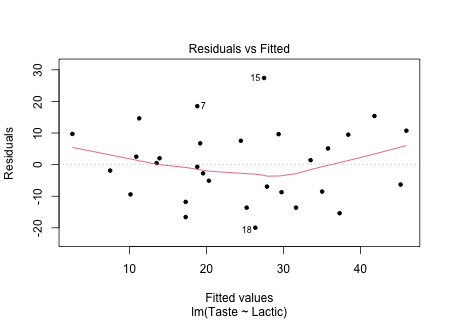

The appropriate graph to check for constant variance is a residual plot. There is no pattern in the residual plot, so we can conclude that there is a constant variance in the data.

3

C

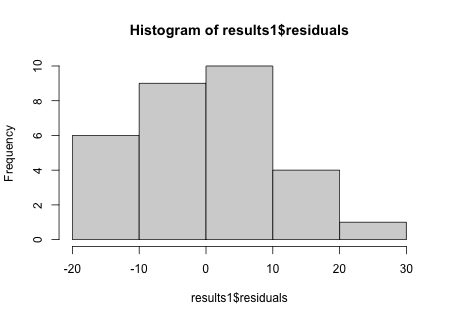

The appropriate graph to check for a normal error term is a histogram of the residuals. The shape of the histogram looks fairly bell-shaped and symmetric, so we can conclude that the error terms are normal.

4

-

$r = 0.704$

5

-

$\hat{Y} = -29.859 + 37.72X$

6

-

$Y = 49.73$

7

-

(22.999, 52.441) We are 95% confident that the slope of the true true linear regression line of Lactic with Taste is between 22.999 and 52.441.

8

-

$H_0: \beta_1 = 0$  
$H_a: \beta_1 \neq 0$

9

-

$t = 5.249$

10

-

$\text{P-value} = 0.00001405$

11

-

reject the null hypothesis

12

-

There is sufficient evidence to suggest that the slope of the true linear regression line does not equal zero. We conclude that there is a linear relationship between the concentration of lactic acid in cheese and the quality of its taste.

13

A

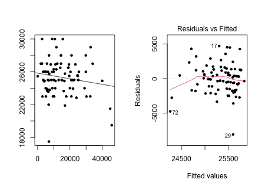

The appropriate graphs to check for a linear relationship are a scatterplot and a residual plot. The scatterplot does not seem to show a significant linear relationship, so we cannot conclude that there is a linear relationship in the data.

13

B

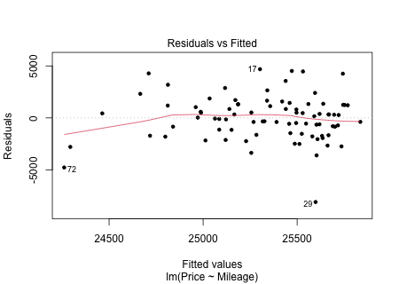

The appropriate graph to check for constant variance is a residual plot. There is no pattern in the residual plot, so we can conclude that there is a constant variance in the data.

13

C

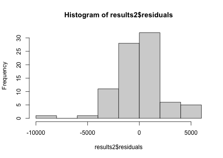

14

-

$\hat{Y} = 25,838.626 + -0.034X$

15

-

$Y = 22,401.192$

16

17

-

$H_0: \beta_1 = 0$  
$H_a: \beta_1 \neq 0$

18

-

$t = -1.476$

19

-

$\text{P-value} = 0.144$

20

-

fail to reject the null hypothesis

21

-

There is insufficient evidence to suggest that the slope of the true linear regression line does not equal zero. We conclude that there is not a linear relationship between the mileage of a Prius listed for sale and its price.

22

-

$r = -0.181$

23

-

$\hat{Y} = 62.825 + -18.236X$

24

-

$Y = 49.148$

25

-

(-41.855, 5.383) We are 95% confident that the slope of the true true linear regression line of Lead with BRS is between -41.855 and 5.383.

26

-

$H_0: \beta_1 = 0$  
$H_a: \beta_1 \neq 0$

27

-

$t = -1.54$

28

-

$\text{P-value} = 0.128$

29

-

fail to reject the null hypothesis

30

-

There is insufficient evidence to suggest that the slope of the true linear regression line does not equal zero. We conclude that there is not a linear relationship between a child’s level of lead exposure and his or her behavioral rating.

31

-

d. The actual `Y` value was 4.5 units higher than the predicted `Y` value